# Self-reported expressibility predicts communicative success: Open dataset, validation, and simulation

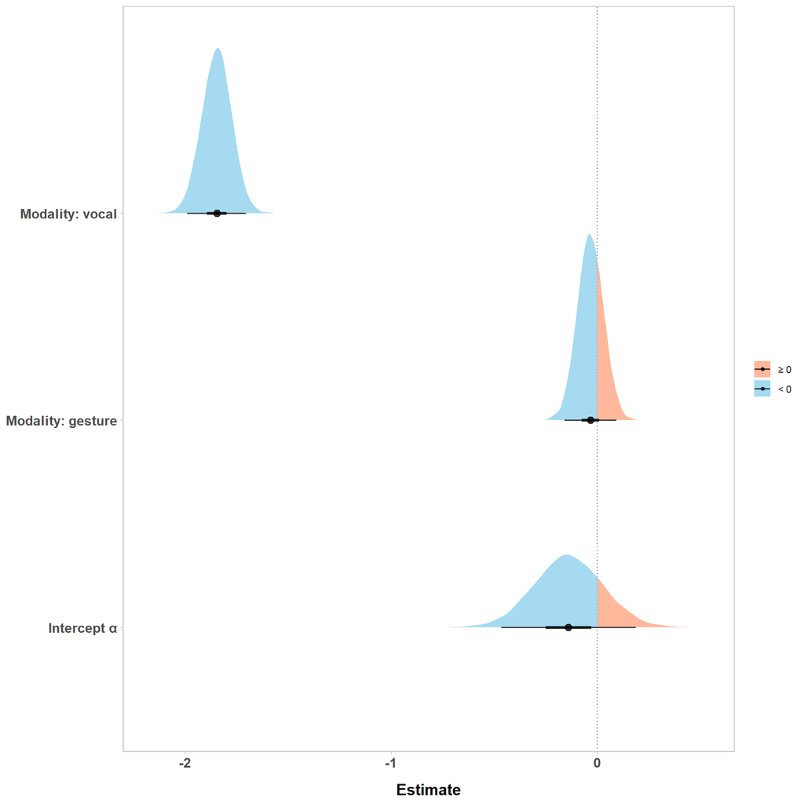

**Figure 83.** Posterior estimates of the fixed effects showing the median (dot), 50% (thick line) and 95% (thin lines) quantiles. Also showing 0 as the vertical dotted line and negative (blue) vs positive (red) values. Figure generated using [`R`](https://www.r-project.org/) version 4.4.1 (2024-06-14 ucrt)

```r
gather_draws(mdl_H4_binary, `b_.*`, regex = TRUE) %>%
    # remove the b_ for plotting
    #mutate(.variable = gsub("b_","", .variable)) %>%
    ggplot(aes(x = .value, y = .variable, fill = after_stat(x < 0))) +
    geom_vline(xintercept=0.0, linetype="dotted", color="gray30") +
    stat_halfeye(alpha=0.75, point_interval=median_qi, .width=c(.50, .95)) +
    scale_fill_manual(values = c("lightsalmon", "skyblue"), name=NULL, labels=c("≥ 0", "< 0")) +
    #xlim(-10, 10) +
    scale_y_discrete(labels=c("b_Intercept" = "Intercept α",
                              "b_modalitygesture" = "Modality: gesture",
                              "b_modalityvocal" = "Modality: vocal")) +
    ylab(NULL) + xlab("Estimate") +
    theme(axis.title.x = element_text(margin = margin(t = 12, b = 0,
                                                      r = 0, l = 0),
                                      face = 'bold', size = 14),
          axis.text.x = element_text(face = 'bold', size = 12),
          axis.text.y = element_text(face = 'bold', size = 12))
```

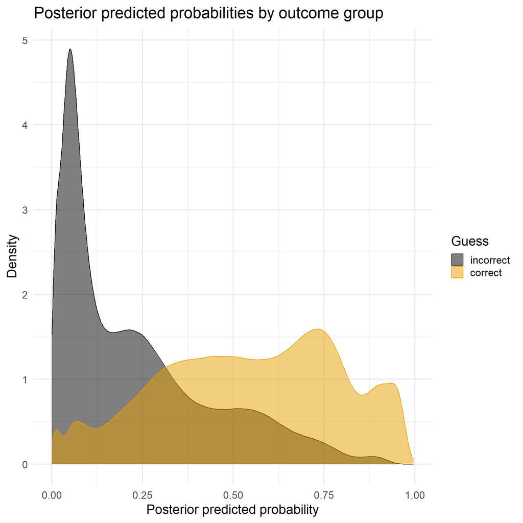

**Figure 84.** Posterior predicted probabilities by outcome group. This density plot is based on individual-level predictions (or a random subset thereof), stratified by guess outcome. The plot shows that predictions for incorrect guesses are tightly concentrated near 0, while predictions for correct guesses are more variable and generally higher, reflecting the model’s ability to distinguish between the two outcomes. Figure generated using [`R`](https://www.r-project.org/) version 4.4.1 (2024-06-14 ucrt)

```r
# # Take a random subset of the data (e.g., 500 observations)
# df_subset <- df %>%
#   filter(!is.na(guess_binary)) %>%
#   sample_n(500)

# Extract posterior draws of the predicted probability for these observations
# The plot takes a while, so if you just need a general overview, use the code above to just take a sample
df_subset %>%
#df %>%
  add_epred_draws(mdl_H4_binary, type = "response") %>%
  ggplot(aes(x = .epred, fill = factor(guess_binary), color = factor(guess_binary))) +
  geom_density(alpha = 0.5, adjust = 1.2) +
  scale_fill_manual(values = c("0" = colorBlindBlack8[1], "1" = colorBlindBlack8[2]),
                    labels = c("incorrect", "correct")) +
  scale_color_manual(values = c("0" = colorBlindBlack8[1], "1" = colorBlindBlack8[2]),
                     labels = c("incorrect", "correct")) +
  labs(
    x = "Posterior predicted probability",
    y = "Density",
    title = "Posterior predicted probabilities by outcome group",
    fill = "Guess", color = "Guess"
  ) +
  theme_minimal(base_size = 18)
```

```r
# ggsave(plot = last_plot(), filename = paste0(plots, "mdl_H3_binary_postByOutcome.pdf"), width = 6, height = 6);
# ggsave(plot = last_plot(), filename = paste0(plots, "mdl_H3_binary_postByOutcome.jpg"), width = 6, height = 6);
# ggsave(plot = last_plot(), filename = paste0(plots, "mdl_H3_binary_postByOutcome.tif"), width = 6, height = 6, compression="lzw", dpi=600);
```

In this plot, the model’s posterior predicted probability is extracted for each individual observation (or for a randomly selected subset). The density curves are then constructed based on these individual-level predictions, separately for observations that are actually incorrect versus correct. Here, you will typically see that the distribution for incorrect guesses is highly concentrated near 0, indicating that most individual predictions for the incorrect group are very low. On the other hand, the distribution for correct guesses is more spread out, showing more variability in the predicted probabilities. This plot therefore reveals not only the overall difference between the two groups but also the within-group variation in predictions.

**Random effects**:

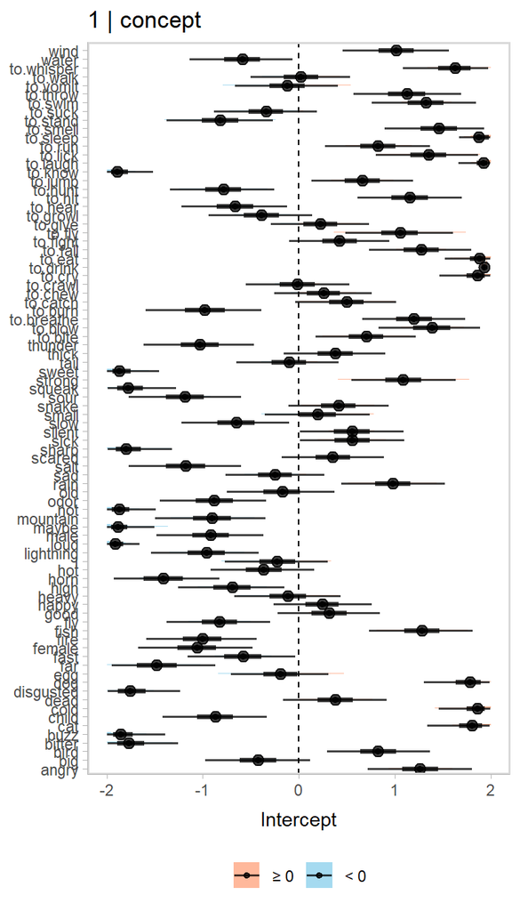

**Figure 85.** Posterior estimates of the random effects showing the median (dot), 50% (thick line) and 95% (thin lines) quantiles. Also showing 0 as the vertical dotted line and negative (blue) vs positive (red) values. Figure generated using [`R`](https://www.r-project.org/) version 4.4.1 (2024-06-14 ucrt)

```r
#get_variables(b1_res_field$b1);
grid.arrange(
  # 1 | concept:
  mdl_H4_binary %>%
    spread_draws(b_Intercept, r_concept[concept]) %>%
    #filter(Order == "Intercept") %>%
    mutate(condition_mean = r_concept) %>%
    ggplot(aes(y = concept, x = condition_mean, fill = after_stat(x < 0))) +
    stat_halfeye(alpha=0.75, point_interval=median_qi, .width=c(.50, .95)) +
    scale_fill_manual(values = c("lightsalmon", "skyblue"), name=NULL, labels=c("≥ 0", "< 0")) +
    geom_vline(xintercept = 0, linetype = "dashed") +
    ggtitle("1 | concept") + xlab("Intercept") + ylab(NULL) + xlim(-2,2) +
    theme(legend.position="bottom"),
  nrow=1)
```

Get a general overview of group-level effects.

| Random Effect | Estimate | Est.Error | Q2.5 | Q97.5 |
| --- | --- | --- | --- | --- |
| Intercept | 1.453849 | 0.1234331 | 1.233387 | 1.717493 |

| Random Effect | Estimate | Est.Error | Q2.5 | Q97.5 |
| --- | --- | --- | --- | --- |
| Intercept | 0.2171161 | 0.04069618 | 0.1397177 | 0.2999349 |

There variance across different concepts is much larger than the variance across different dyads.

We can plot the variance across the concepts extracting draws.

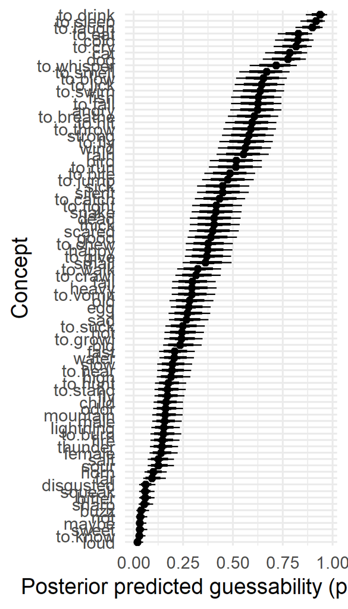

**Figure 86.** Posterior binary guessability of concepts showing the median (dot), 50% (thick line), 80% (medium thick line), and 95% (thin lines) quantiles. Figure generated using [`R`](https://www.r-project.org/) version 4.4.1 (2024-06-14 ucrt)

```r
mdl_H4_binary %>%
  spread_draws(r_concept[concept]) %>%
  # Combine the fixed intercept with the concept-specific random effect
  mutate(mu_concept = fixef(mdl_H3_binary)["Intercept", "Estimate"] + r_concept) %>%
  # Back-transform from the logit scale to probabilities
  mutate(guessability = plogis(mu_concept)) %>%
  median_qi(guessability, .width = c(0.5, 0.8, 0.95)) %>%
  ggplot(aes(x = guessability, y = fct_reorder(concept, guessability))) +
  geom_pointinterval(aes(xmin = .lower, xmax = .upper),
                     position = position_dodge(width = 0.1)) +
  labs(
    x = "Posterior predicted guessability (probability)",
    y = "Concept"
  ) +
  theme_minimal(base_size = 18)
```

```r
df %>%
  filter(!is.na(guess_binary)) %>%
  group_by(concept) %>%
  summarize(prop = mean(as.numeric(as.character(guess_binary))), .groups = "drop") %>%
  ggplot(aes(x = prop, y = fct_reorder(concept, prop))) +
  geom_point(color = "black", size = 3) +
  labs(
    x = "Observed guessability (proportion correct)",
    y = "Concept"
  ) +
  theme_minimal(base_size = 18)
```

**Interpretation**: This model tested whether *guessability* differs by *modality* (combined, gesture, vocal). The intercept of −0.14 on the log‐odds scale corresponds to an overall predicted probability of a correct guess of roughly **46% in the combined** condition (95% credible interval ≈ 38–54%). The coefficient for gesture (−0.03) is very close to zero, indicating almost no difference between combined (about 46%) and gesture (about 45%) – the posterior probability that combined is higher than gesture is only about 70%, so there is no strong evidence of a difference. By contrast, the coefficient for vocal (−1.85) is markedly negative, producing a **predicted probability of only about 12%** (95% CI roughly 10–15%) in the vocal condition. Posterior hypothesis tests confirm that both combined and gesture yield substantially higher guessability than vocal (nearly 100% posterior certainty), whereas **combined vs. gesture are statistically indistinguishable**.

In practical terms, these results partially support the hypothesis that guessability differs by modality, but the data show no credible difference between combined and gesture; both are much higher than vocal. This means that performing a concept with only vocal signals strongly decreases the probability that a partner guesses correctly, while using either gesture alone or a combined multimodal signal achieves comparable (and substantially better) success rates.

## 8.2 Guess similarity

Preregistered model: `guessability_similarity ~ modality + (1 | dyad/participant) + (1 | concept)`

```r
mdl_H4_similarity <- readRDS(paste0(models, "mdl_H4_similarity.rds"))
```

Calculate R².

```
##      Estimate   Est.Error       Q2.5      Q97.5
## R2 0.06237911 0.002670334 0.05719921 0.06770391
```

R^2 is 0.0623791 suggesting that 6.2379106% of the variance in the outcome variable are explained by the model.

**Diagnostic plots**:

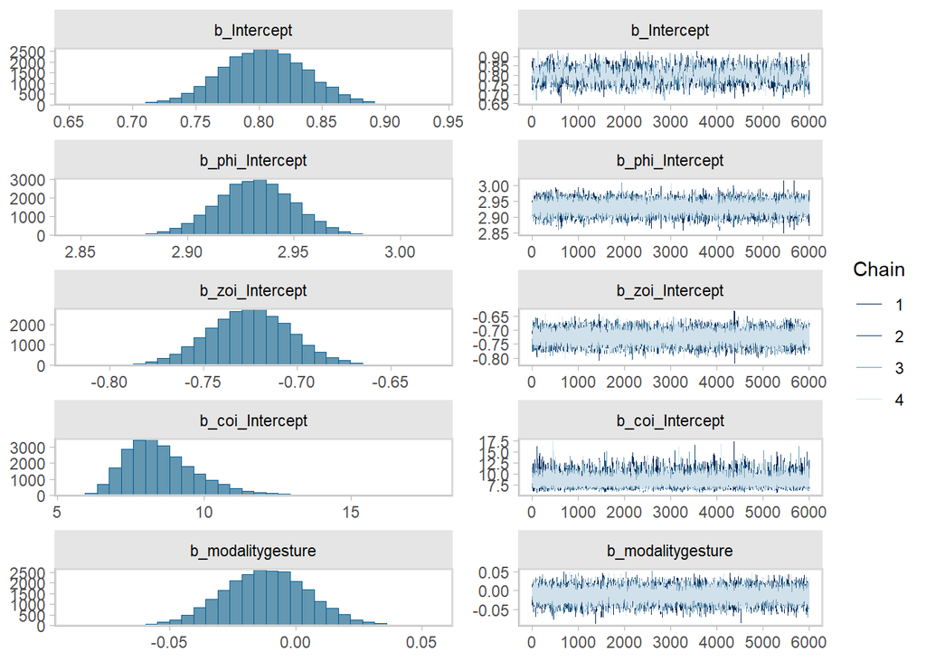

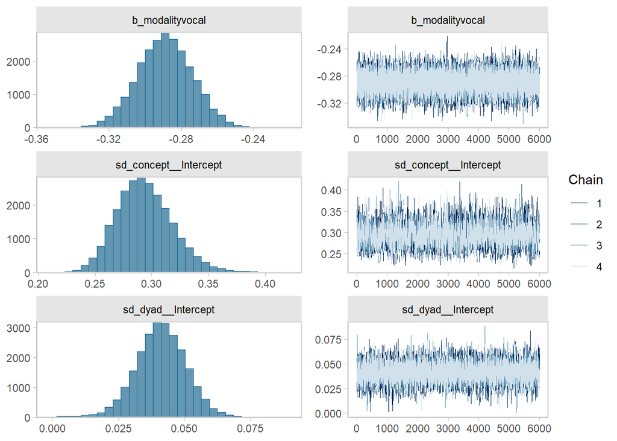

```r
plot(mdl_H4_similarity)
```

**Convergence**: All convergence diagnostics are excellent (Rhat = 1.00).

```r
summary(mdl_H4_similarity)
```

```
##  Family: zero_one_inflated_beta
##   Links: mu = logit; phi = log; zoi = logit; coi = logit
## Formula: cosine_similarity ~ modality + (1 | dyad) + (1 | concept)
##          phi ~ 1
##          zoi ~ 1
##          coi ~ 1
##    Data: df (Number of observations: 8982)
##   Draws: 4 chains, each with iter = 10000; warmup = 4000; thin = 1;
##          total post-warmup draws = 24000
##
## Multilevel Hyperparameters:
## ~concept (Number of levels: 84)
##               Estimate Est.Error l-95% CI u-95% CI Rhat Bulk_ESS Tail_ESS
## sd(Intercept)     0.29      0.02     0.25     0.35 1.00     3310     7521
##
## ~dyad (Number of levels: 71)
##               Estimate Est.Error l-95% CI u-95% CI Rhat Bulk_ESS Tail_ESS
## sd(Intercept)     0.04      0.01     0.02     0.06 1.00     7887     7223
##
## Regression Coefficients:
##                 Estimate Est.Error l-95% CI u-95% CI Rhat Bulk_ESS Tail_ESS
## Intercept           0.80      0.03     0.74     0.87 1.00     2057     4552
## phi_Intercept       2.93      0.02     2.90     2.97 1.00    41929    17900
## zoi_Intercept      -0.73      0.02    -0.77    -0.68 1.00    45519    17333
## coi_Intercept       8.56      1.27     6.67    11.60 1.00    28883    12126
## modalitygesture    -0.01      0.02    -0.05     0.02 1.00    28549    19285
## modalityvocal      -0.29      0.02    -0.32    -0.26 1.00    27951    19811
##
## Draws were sampled using sampling(NUTS). For each parameter, Bulk_ESS
## and Tail_ESS are effective sample size measures, and Rhat is the potential
## scale reduction factor on split chains (at convergence, Rhat = 1).
```

```
## No divergences to plot.
```

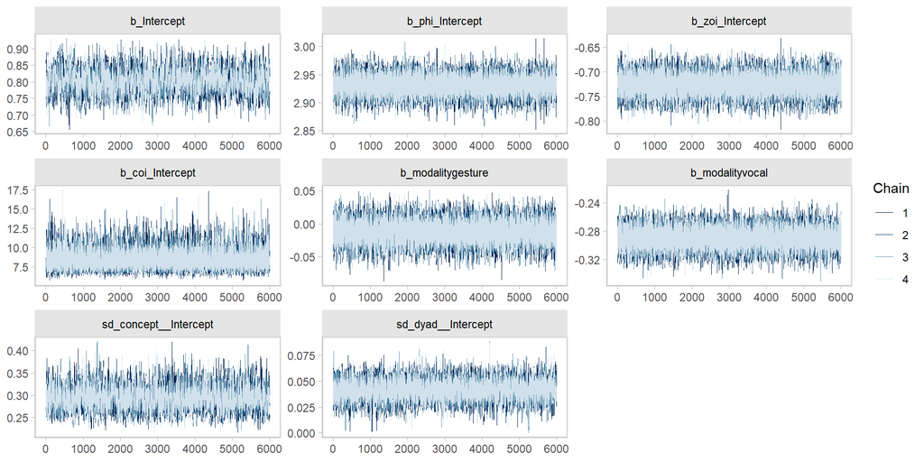

**Figure 88.** Trace of the fitting process. Figure generated using [`R`](https://www.r-project.org/) version 4.4.1 (2024-06-14 ucrt)

```r
mcmc_plot(mdl_H4_similarity, type="trace");
```

**Posterior predictive checks**: Modeling the density of the bimodal distribution is far from ideal.

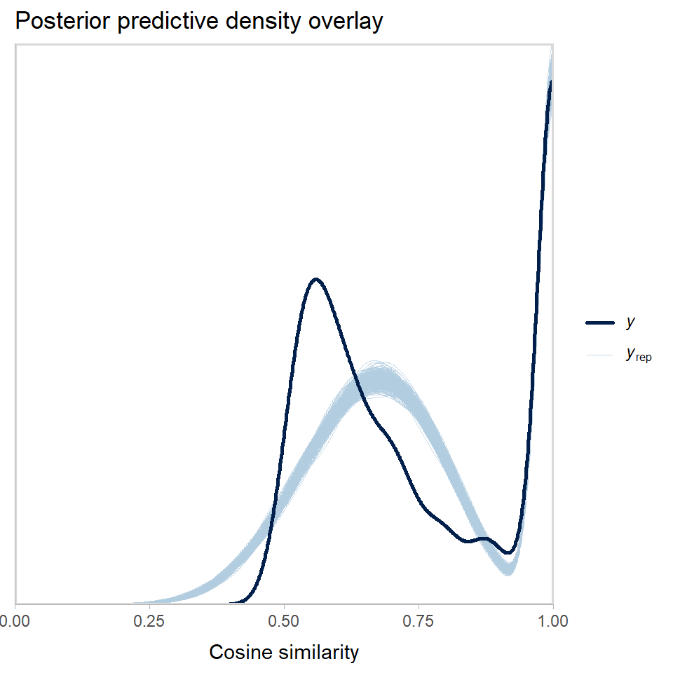

**Figure 89.** Posterior predictive density overlay for n=500 draws. Figure generated using [`R`](https://www.r-project.org/) version 4.4.1 (2024-06-14 ucrt)

```r
pp_check(mdl_H4_similarity, ndraws=500) + xlab('Cosine similarity') + ggtitle('Posterior predictive density overlay');
```

```
## Using all posterior draws for ppc type 'stat' by default.
## Using all posterior draws for ppc type 'stat' by default.
## Using all posterior draws for ppc type 'stat' by default.
```

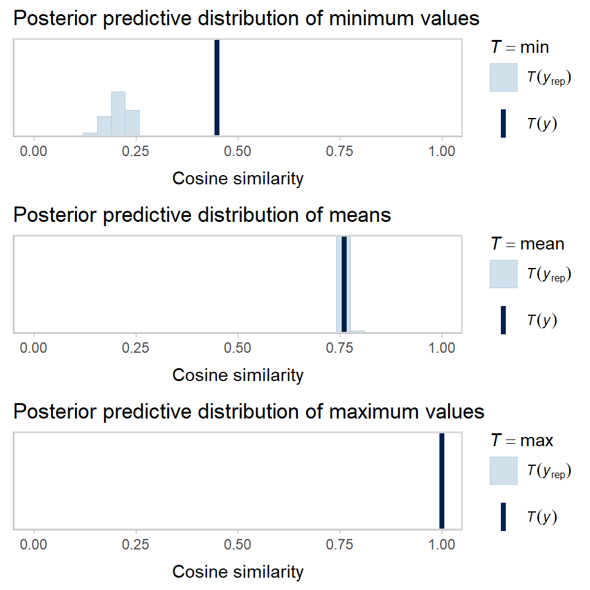

**Figure 90.** Posterior predictive distribution. Figure generated using [`R`](https://www.r-project.org/) version 4.4.1 (2024-06-14 ucrt)

```r
grid.arrange(pp_check(mdl_H4_similarity, type='stat', sta ='min') + xlab('Cosine similarity') + ggtitle('Posterior predictive distribution of minimum values') + xlim(0,1),
             pp_check(mdl_H4_similarity, type='stat', stat='mean') + xlab('Cosine similarity') + ggtitle('Posterior predictive distribution of means') + xlim(0,1),
             pp_check(mdl_H4_similarity, type='stat', stat='max') + xlab('Cosine similarity') + ggtitle('Posterior predictive distribution of maximum values') + xlim(0,1),
             ncol=1);
```

**Fixed effects**:

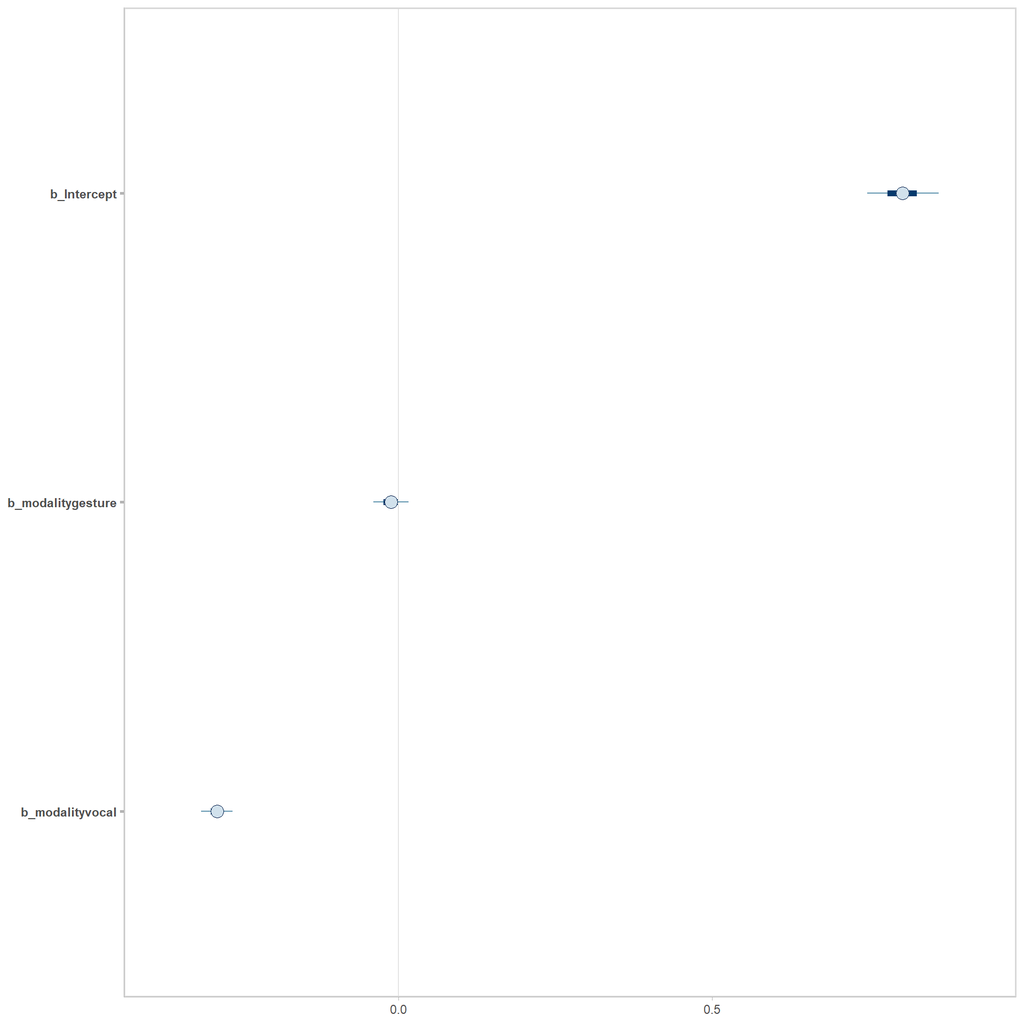

**Figure 91.** Fixed effects’ posterior distributions. Figure generated using [`R`](https://www.r-project.org/) version 4.4.1 (2024-06-14 ucrt)

```r
mcmc_plot(mdl_H4_similarity, variable=c("b_Intercept","b_modalitygesture","b_modalityvocal"));
```

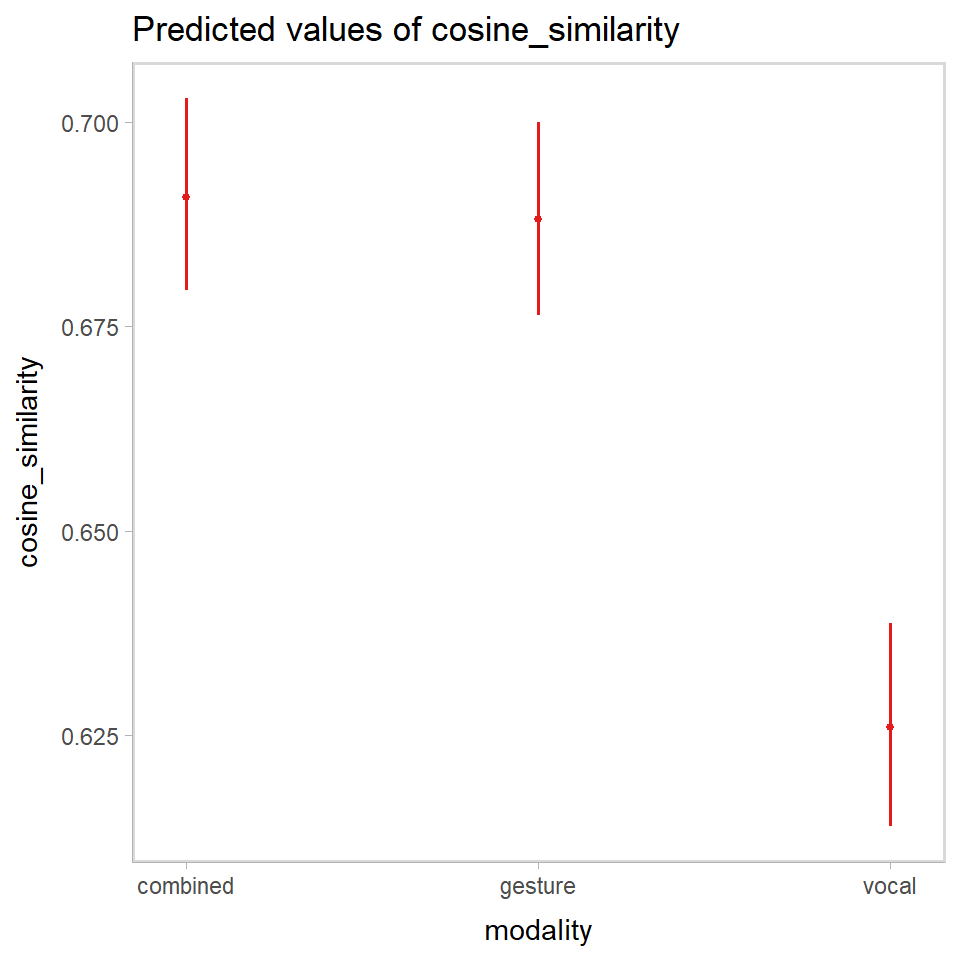

**Figure 92.** Fixed effects. Figure generated using [`R`](https://www.r-project.org/) version 4.4.1 (2024-06-14 ucrt)

```r
plot_model(mdl_H4_similarity, type="emm", terms=c("modality"));
```

```r
emmeans(mdl_H4_similarity, ~ modality)
```

```
##  modality emmean lower.HPD upper.HPD
##  combined  0.804     0.737     0.873
##  gesture   0.792     0.726     0.859
##  vocal     0.515     0.450     0.580
##
## Point estimate displayed: median
## Results are given on the logit (not the response) scale.
## HPD interval probability: 0.95
```

```r
emmeans(mdl_H4_similarity, ~ modality, type = "response")
```

```
##  modality response lower.HPD upper.HPD
##  combined    0.691     0.676     0.705
##  gesture     0.688     0.674     0.703
##  vocal       0.626     0.611     0.641
##
## Point estimate displayed: median
## Results are back-transformed from the logit scale
## HPD interval probability: 0.95
```

```r
pairs(emmeans(mdl_H4_similarity, ~ modality))
```

```
##  contrast           estimate lower.HPD upper.HPD
##  combined - gesture    0.012   -0.0221    0.0447
##  combined - vocal      0.289    0.2585    0.3178
##  gesture - vocal       0.277    0.2475    0.3074
##
## Point estimate displayed: median
## Results are given on the log odds ratio (not the response) scale.
## HPD interval probability: 0.95
```

```r
pairs(emmeans(mdl_H4_similarity, ~ modality, type = "response"))
```

```
##  contrast           odds.ratio lower.HPD upper.HPD
##  combined / gesture       1.01     0.978      1.05
##  combined / vocal         1.34     1.295      1.37
##  gesture / vocal          1.32     1.281      1.36
##
## Point estimate displayed: median
## Results are back-transformed from the log odds ratio scale
## HPD interval probability: 0.95
```

```r
back_transform_zoib(
  fixef(mdl_H4_similarity, dpar = "mu")["Intercept", "Estimate"],
  fixef(mdl_H4_similarity, dpar = "zoi")["Intercept", "Estimate"]
)
```

```
## [1] 0.7864056
```

```r
bayestestR::hdi(mdl_H4_similarity, ci=0.95)
```

|  | Parameter | CI | CI_low | CI_high | Effects | Component |
| --- | --- | --- | --- | --- | --- | --- |
| 2 | b_Intercept | 0.95 | 0.73721724 | 0.87333799 | fixed | conditional |
| 5 | b_phi_Intercept | 0.95 | 2.89628246 | 2.96685956 | fixed | conditional |
| 6 | b_zoi_Intercept | 0.95 | -0.76861760 | -0.68136988 | fixed | conditional |
| 1 | b_coi_Intercept | 0.95 | 6.43752050 | 11.12117588 | fixed | conditional |
| 3 | b_modalitygesture | 0.95 | -0.04468293 | 0.02213209 | fixed | conditional |
| 4 | b_modalityvocal | 0.95 | -0.31784852 | -0.25845445 | fixed | conditional |

```r
hypothesis(mdl_H4_similarity, c("modalitygesture < 0",
                            "modalityvocal < 0"
                            ))
```

```
## Hypothesis Tests for class b:
##              Hypothesis Estimate Est.Error CI.Lower CI.Upper Evid.Ratio
## 1 (modalitygesture) < 0    -0.01      0.02    -0.04     0.02       3.15
## 2   (modalityvocal) < 0    -0.29      0.02    -0.31    -0.26        Inf
##   Post.Prob Star
## 1      0.76
## 2      1.00    *
## ---
## 'CI': 90%-CI for one-sided and 95%-CI for two-sided hypotheses.
## '*': For one-sided hypotheses, the posterior probability exceeds 95%;
## for two-sided hypotheses, the value tested against lies outside the 95%-CI.
## Posterior probabilities of point hypotheses assume equal prior probabilities.
```

```r
hypothesis(mdl_H4_similarity, c(
  # Combined > Gesture:
  "inv_logit_scaled(Intercept) > inv_logit_scaled(Intercept + modalitygesture)",
  # Combined > Vocal:
  "inv_logit_scaled(Intercept) > inv_logit_scaled(Intercept + modalityvocal)",
  # Gesture > Vocal:
  "inv_logit_scaled(Intercept + modalitygesture) > inv_logit_scaled(Intercept + modalityvocal)"
))
```

```
## Hypothesis Tests for class b:
##                 Hypothesis Estimate Est.Error CI.Lower CI.Upper Evid.Ratio
## 1 (inv_logit_scaled... > 0     0.00         0     0.00     0.01       3.15
## 2 (inv_logit_scaled... > 0     0.06         0     0.06     0.07        Inf
## 3 (inv_logit_scaled... > 0     0.06         0     0.06     0.07        Inf
##   Post.Prob Star
## 1      0.76
## 2      1.00    *
## 3      1.00    *
## ---
## 'CI': 90%-CI for one-sided and 95%-CI for two-sided hypotheses.
## '*': For one-sided hypotheses, the posterior probability exceeds 95%;
## for two-sided hypotheses, the value tested against lies outside the 95%-CI.
## Posterior probabilities of point hypotheses assume equal prior probabilities.
```

```r
# Let's build newdata for each modality level:
newdata_mod <- data.frame(modality = c("combined","gesture","vocal"))

# Posterior predictions (on the response scale) ignoring random effects, or re_formula=NA
post_mod <- add_epred_draws(mdl_H4_similarity, newdata = newdata_mod, re_formula=NA)

# Summarize each condition
post_mod_summary <- post_mod %>%
  group_by(modality) %>%
  mean_qi(.epred, .width=c(0.95))  # .epred is on the response scale (0..1)

post_mod_summary
```

| modality | .epred | .lower | .upper | .width | .point | .interval |
| --- | --- | --- | --- | --- | --- | --- |
| combined | 0.7915372 | 0.7812097 | 0.8016448 | 0.95 | mean | qi |
| gesture | 0.7898088 | 0.7795119 | 0.7999541 | 0.95 | mean | qi |
| vocal | 0.7478494 | 0.7369245 | 0.7587207 | 0.95 | mean | qi |

**Intercept**:  
The model yields an estimated intercept for the β‐component (mu submodel) of 0.80 95%CI [0.74, 0.87] on the log‐odds scale. Because our model is specified in terms of a zero–one inflated beta, this intercept represents the baseline log‐odds for the beta portion (i.e., the “regular” responses) when **modality** is *combined*. Converting via the inverse‐logit suggests that, ignoring any inflation, the beta part alone predicts roughly 69.1% similarity for *combined*.

**Modality**:  
We include *gesture* and *vocal* as predictors in the mu submodel (combined was the Intercept). The effect of *gesture* is estimated at -0.01 95%CI [-0.05, 0.02] on the log‐odds scale, indicating almost no difference from *combined*. Indeed, the overall posterior mean for *gesture* is about 79.0% 95%CI [78.0%, 80.0%] (similar to combined).

By contrast, the coefficient for *vocal* is -0.29 95%CI [-0.32, -0.26], implying a modest but credible drop in similarity. Indeed, *vocal* yields a mean similarity of 74.8% 95%CI [73.7%, 75.9%].

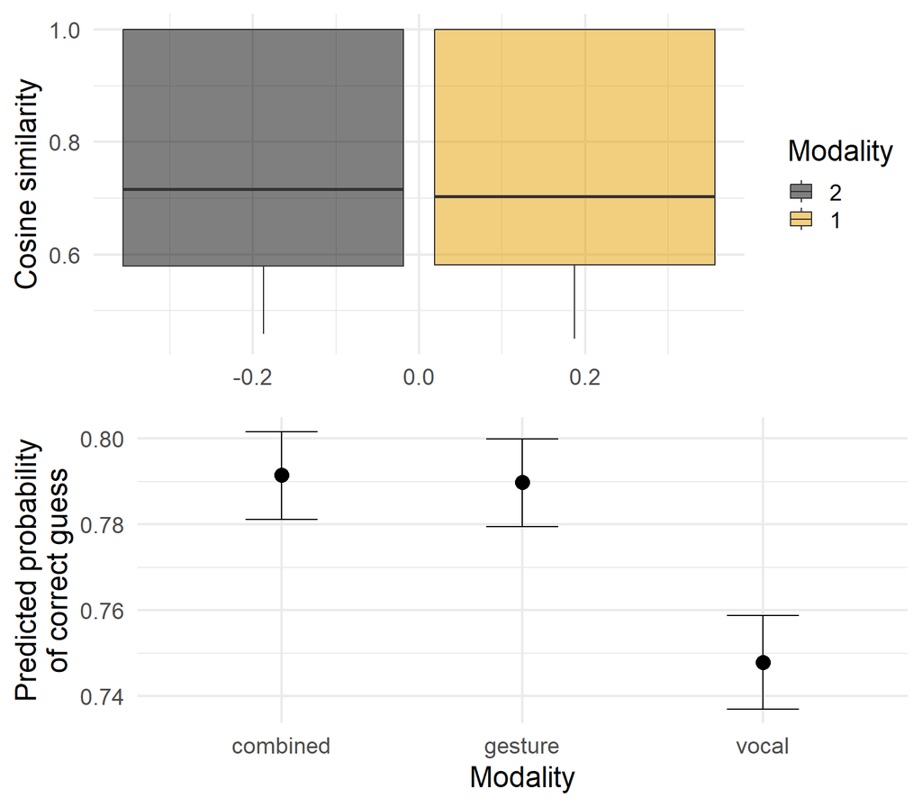

```r
# Panel 1: Averaged cosine similarity x expressibility
p_obs <- df %>%
  filter(!is.na(cosine_similarity)) %>%
  ggplot(aes(y = cosine_similarity, fill = factor(exp_part))) +
  geom_boxplot(alpha = 0.5) +
  scale_fill_manual(values = c("1" = colorBlindBlack8[1], "2" = colorBlindBlack8[2]),
                    labels = c("2", "1")) +
  labs(y = "Cosine similarity", y = "Modality", fill = "Modality") +
  theme_minimal(base_size = 18)

# Panel 2: Conditional effects of expressibility_dutch on predicted probability
ce_exp <- conditional_effects(mdl_H4_similarity, effects = "modality")
p_pred <- plot(ce_exp, plot = FALSE)[[1]] +
  labs(x = "Modality", y = "Predicted probability\nof correct guess") +
  theme_minimal(base_size = 18)

# Arrange the two panels vertically using grid.arrange
grid.arrange(p_obs, p_pred, ncol = 1)
```

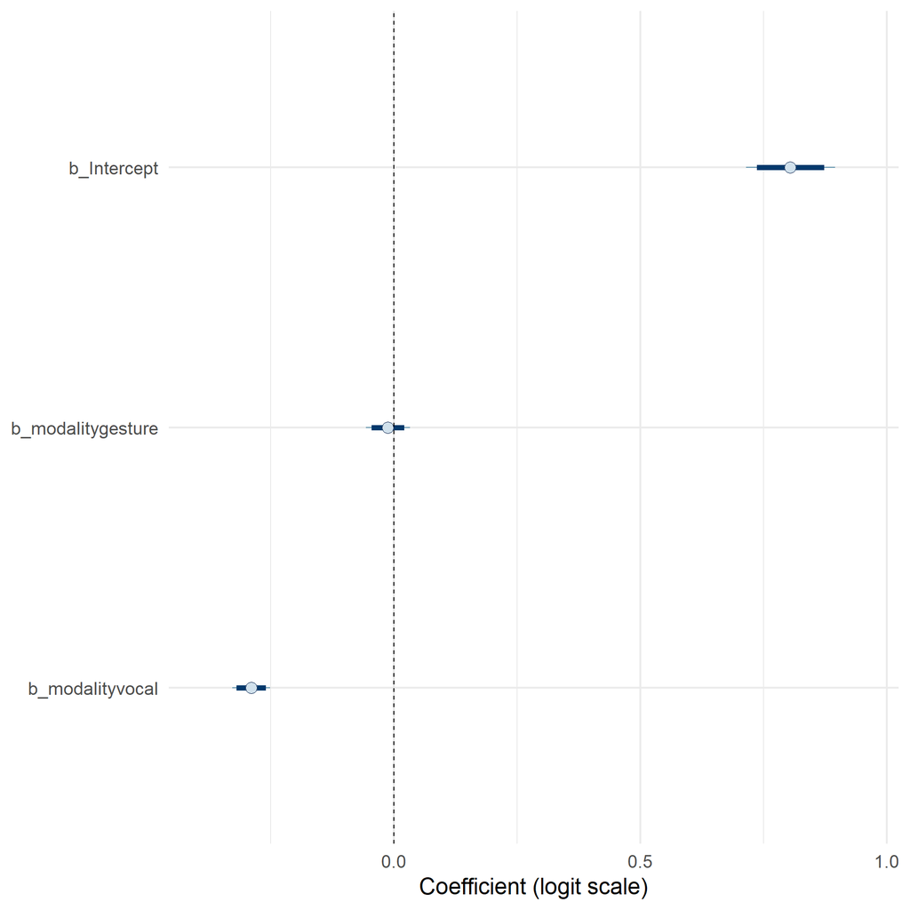

**Figure 94.** Posterior draws for the fixed effects. Figure generated using [`R`](https://www.r-project.org/) version 4.4.1 (2024-06-14 ucrt)

```r
# Extract posterior draws for the fixed effects
# For our binary model, the coefficients are on the logit scale.
posterior_fixed <- as.matrix(mdl_H4_similarity, variable = c("b_Intercept", "b_modalitygesture", "b_modalityvocal"))

# Plot using mcmc_intervals; we add a dashed vertical line at 0 for reference.
mcmc_intervals(posterior_fixed, prob = 0.95, prob_outer = 0.99) +
  geom_vline(xintercept = 0, linetype = "dashed") +
  labs(
    x = "Coefficient (logit scale)"
  ) +
  theme_minimal(base_size = 18)
```

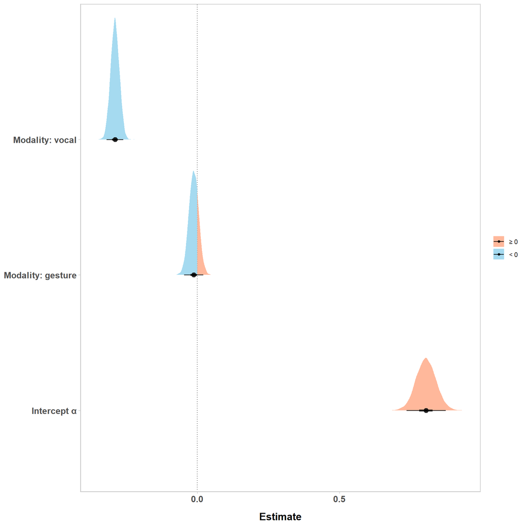

**Figure 95.** Posterior estimates of the fixed effects showing the median (dot), 50% (thick line) and 95% (thin lines) quantiles. Also showing 0 as the vertical dotted line and negative (blue) vs positive (red) values. Figure generated using [`R`](https://www.r-project.org/) version 4.4.1 (2024-06-14 ucrt)

```r
gather_draws(mdl_H4_similarity, `b_.*`, regex = TRUE) %>%
    # remove the b_ for plotting
    filter(.variable == c("b_Intercept", "b_modalitygesture", "b_modalityvocal")) %>%
    ggplot(aes(x = .value, y = .variable, fill = after_stat(x < 0))) +
    geom_vline(xintercept=0.0, linetype="dotted", color="gray30") +
    stat_halfeye(alpha=0.75, point_interval=median_qi, .width=c(.50, .95)) +
    scale_fill_manual(values = c("lightsalmon", "skyblue"), name=NULL, labels=c("≥ 0", "< 0")) +
    #xlim(-10, 10) +
    scale_y_discrete(labels=c("b_Intercept" = "Intercept α",
                              "b_modalitygesture" = "Modality: gesture",
                              "b_modalityvocal" = "Modality: vocal")) +
    ylab(NULL) + xlab("Estimate") +
    theme(axis.title.x = element_text(margin = margin(t = 12, b = 0,
                                                      r = 0, l = 0),
                                      face = 'bold', size = 14),
          axis.text.x = element_text(face = 'bold', size = 12),
          axis.text.y = element_text(face = 'bold', size = 12))
```

**Random effects**:

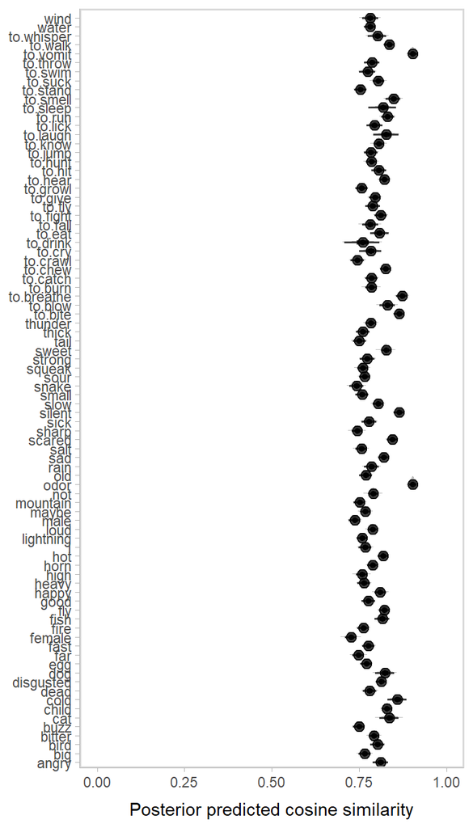

```r
#get_variables(b1_res_field$b1);
grid.arrange(
  # 1 | concept:
  mdl_H4_similarity %>%
  spread_draws(b_Intercept, r_concept[concept]) %>%
  # Add the fixed intercept for mu to the concept-specific random effect:
  mutate(mu_concept = fixef(mdl_H4_similarity, dpar = "mu")["Intercept", "Estimate"] + r_concept) %>%
  # Back-transform to the original scale using the common inflation parameter from zoi:
  mutate(guessability = back_transform_zoib(mu_concept, fixef(mdl_H3_similarity, dpar = "zoi")["Intercept", "Estimate"])) %>%
  ggplot(aes(y = concept, x = guessability)) +
  stat_halfeye(alpha = 0.75, point_interval = median_qi, .width = c(0.50, 0.95)) +
  # scale_fill_manual(values = c("lightsalmon", "skyblue"),
  #                   name = NULL, labels = c("≥ 0.5", "< 0.5")) +
  #geom_vline(xintercept = 0.5, linetype = "dashed") +
  #ggtitle("Posterior estimates of concept-level\ncosine similarity") +
  xlab("Posterior predicted cosine similarity") +
  ylab(NULL) +
  xlim(0, 1) +
    theme(legend.position="bottom"),
  nrow=1)
```

Get a general overview of the group-level effects.

| Random Effect | Estimate | Est.Error | Q2.5 | Q97.5 |
| --- | --- | --- | --- | --- |
| Intercept | 0.2938433 | 0.02483346 | 0.2497229 | 0.3468487 |

| Random Effect | Estimate | Est.Error | Q2.5 | Q97.5 |
| --- | --- | --- | --- | --- |
| Intercept | 0.04109889 | 0.009515726 | 0.02200978 | 0.05935973 |

There is more variance across different concepts than across different dyads.

We can plot the variance across the concepts extracting draws.

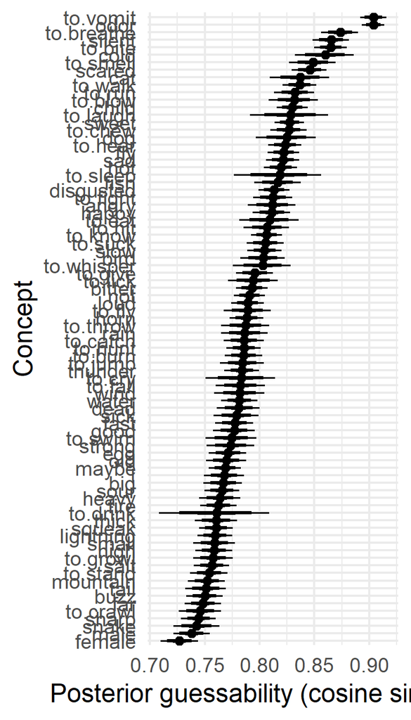

**Figure 97.** Posterior cosine similarity of concepts showing the median (dot), 50% (thick line), 80% (medium thick line), and 95% (thin lines) quantiles. Figure generated using [`R`](https://www.r-project.org/) version 4.4.1 (2024-06-14 ucrt)

```r
# 1 | concept
mdl_H4_similarity %>%
  spread_draws(r_concept[concept, dyad]) %>%
  # Combine the fixed intercept (mu) with the concept-specific random effect.
  mutate(mu_concept = fixef(mdl_H4_similarity, dpar = "mu")["Intercept", "Estimate"] + r_concept) %>%
  # Back-transform to the response scale using the common inflation parameter:
  mutate(guessability = back_transform_zoib(mu_concept, fixef(mdl_H3_similarity, dpar = "zoi")["Intercept", "Estimate"])) %>%
  median_qi(guessability, .width = c(0.5, 0.8, 0.95)) %>%
  ggplot(aes(x = guessability, y = fct_reorder(concept, guessability))) +
  geom_pointinterval(aes(xmin = .lower, xmax = .upper), position = position_dodge(width = 0.1)) +
  labs(
    x = "Posterior guessability (cosine similarity)",
    y = "Concept"
  ) +
  theme_minimal(base_size = 18)
```

```r
df %>%
  filter(!is.na(cosine_similarity)) %>%
  group_by(concept) %>%
  median_qi(cosine_similarity, .width = c(0.5, 0.8, 0.95)) %>%
  ggplot(aes(x = cosine_similarity, y = fct_reorder(concept, cosine_similarity))) +
  geom_pointinterval(aes(xmin = .lower, xmax = .upper),
                     position = position_dodge(width = 0.1)) +
  labs(
    x = "Raw cosine similarity",
    y = "Concept"
  ) +
  theme_minimal(base_size = 18)
```

**Interpretation**: This zero–one inflated beta model tested whether cosine similarity (i.e., how close the guesser’s label is to the target) differs by modality (combined, gesture, vocal). The baseline (combined) intercept is around 0.80 on the log‐odds scale, corresponding to a mean predicted similarity of roughly 79% (95% CI [78%, 80%]). The coefficient for gesture (−0.01) is very close to zero, indicating that gesture alone yields virtually the same similarity as combined (around 79%, 95% CI [78%, 80%]). By contrast, the coefficient for vocal (−0.29) is credibly negative, producing a predicted mean similarity of 75% (95% CI [74%, 76%])—still high, but clearly lower than either combined or gesture. Posterior hypothesis tests confirm that combined ≈ gesture, both higher than vocal with near‐100% posterior certainty. Thus, while the difference is modest in absolute terms (79% vs. 75%), the vocal condition does reduce guess similarity compared to using gesture or a combined signal, suggesting that **vocal‐only expressions may be slightly less transparent to a guesser**.

# 9 Combined H1, H3, and H4

## 9.1 Guess binary

R² is 0.3376113 suggesting that 33.7611319% of the variance in the outcome variable is explained by the model.

**Diagnostic plots**:

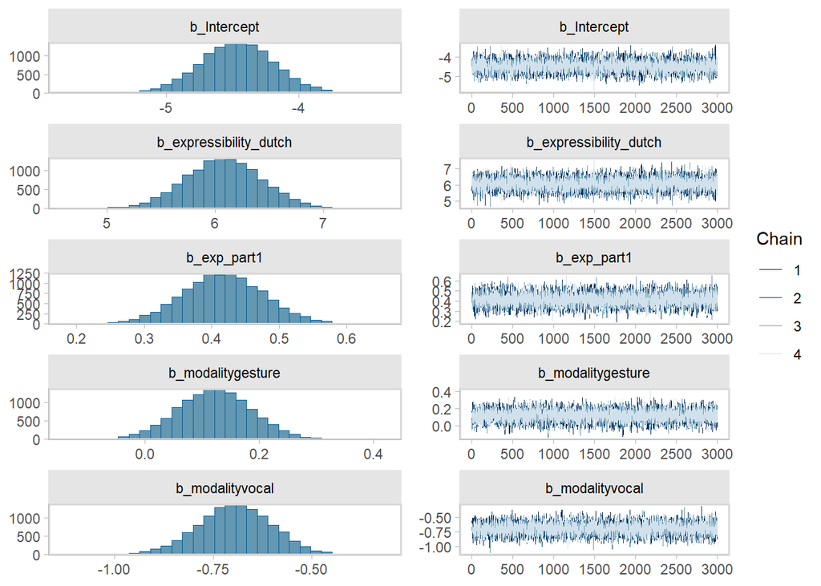

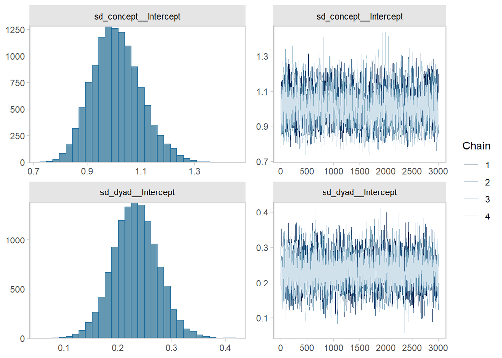

```r
plot(mdl_comb_bin_res)
```

**Convergence**: All convergence diagnostics are excellent (Rhat = 1.00).

```r
summary(mdl_comb_bin_res)
```

```
##  Family: bernoulli
##   Links: mu = logit
## Formula: guess_binary ~ 1 + expressibility_dutch + exp_part + modality + (1 | dyad) + (1 | concept)
##    Data: df (Number of observations: 8989)
##   Draws: 4 chains, each with iter = 10000; warmup = 4000; thin = 2;
##          total post-warmup draws = 12000
##
## Multilevel Hyperparameters:
## ~concept (Number of levels: 84)
##               Estimate Est.Error l-95% CI u-95% CI Rhat Bulk_ESS Tail_ESS
## sd(Intercept)     1.01      0.09     0.85     1.20 1.00     4451     7079
##
## ~dyad (Number of levels: 71)
##               Estimate Est.Error l-95% CI u-95% CI Rhat Bulk_ESS Tail_ESS
## sd(Intercept)     0.23      0.04     0.15     0.32 1.00     7570     9049
##
## Regression Coefficients:
##                      Estimate Est.Error l-95% CI u-95% CI Rhat Bulk_ESS
## Intercept               -4.46      0.28    -5.01    -3.91 1.00     6653
## expressibility_dutch     6.08      0.36     5.39     6.78 1.00     8754
## exp_part1                0.42      0.06     0.30     0.54 1.00     9983
## modalitygesture          0.12      0.06    -0.01     0.25 1.00     9429
## modalityvocal           -0.69      0.09    -0.88    -0.51 1.00     8972
##                      Tail_ESS
## Intercept                9441
## expressibility_dutch    10021
## exp_part1                9621
## modalitygesture          9881
## modalityvocal           10623
##
## Draws were sampled using sampling(NUTS). For each parameter, Bulk_ESS
## and Tail_ESS are effective sample size measures, and Rhat is the potential
## scale reduction factor on split chains (at convergence, Rhat = 1).
```

```
## No divergences to plot.
```

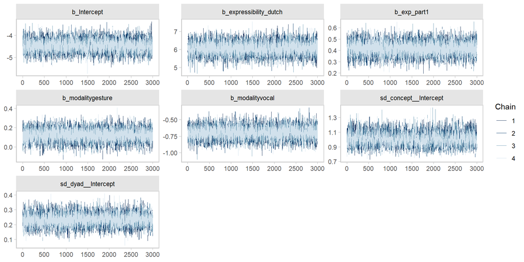

**Figure 99.** Trace of the fitting process. Figure generated using [`R`](https://www.r-project.org/) version 4.4.1 (2024-06-14 ucrt)

```r
mcmc_plot(mdl_comb_bin_res, type="trace");
```

**Posterior predictive checks**: Looking good.

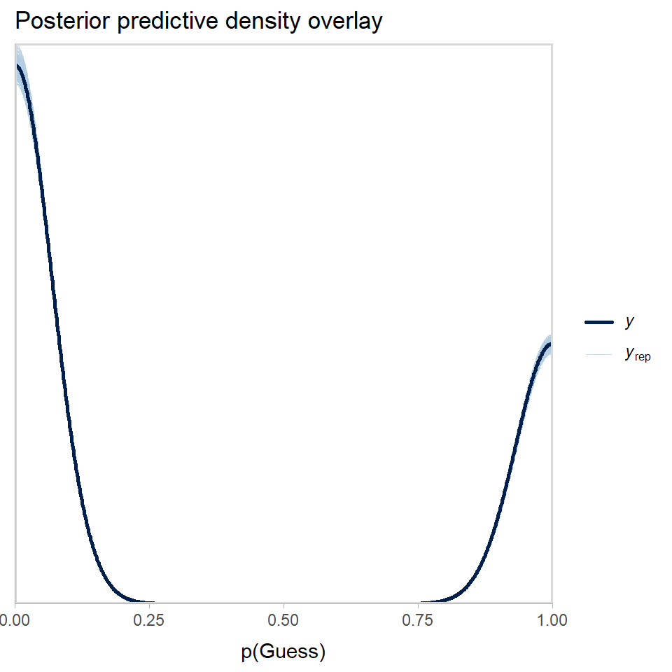

**Figure 100.** Posterior predictive density overlay for n=500 draws. Figure generated using [`R`](https://www.r-project.org/) version 4.4.1 (2024-06-14 ucrt)

```r
pp_check(mdl_comb_bin_res, ndraws=500) + xlab('p(Guess)') + ggtitle('Posterior predictive density overlay');
```

```
## Using all posterior draws for ppc type 'stat' by default.
## Using all posterior draws for ppc type 'stat' by default.
## Using all posterior draws for ppc type 'stat' by default.
```

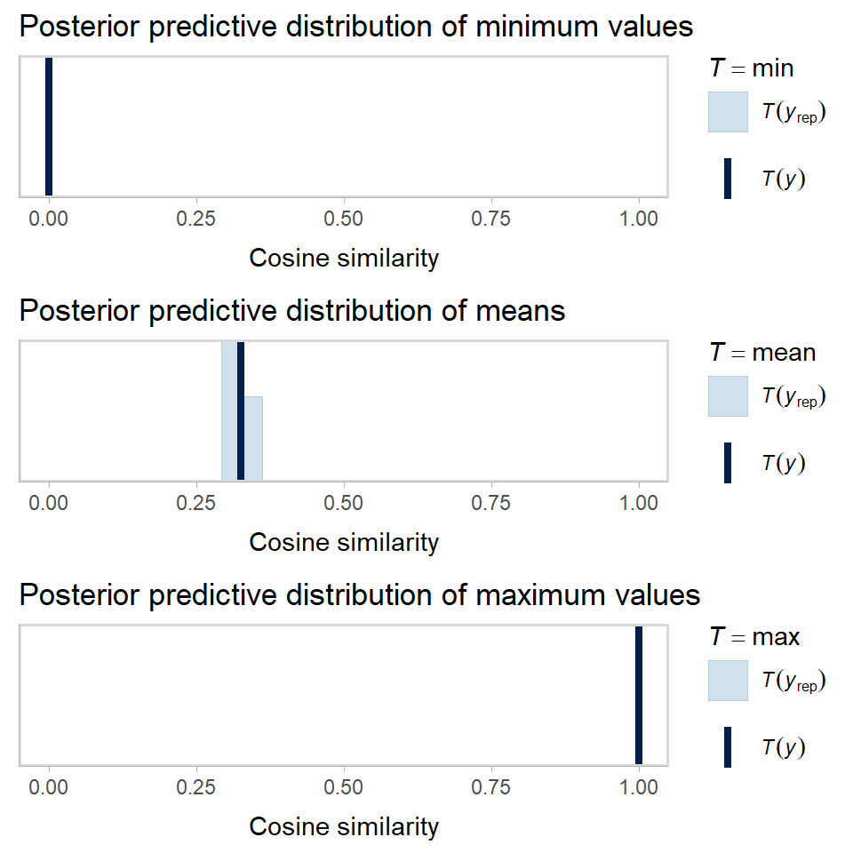

**Figure 101.** Posterior predictive distribution. Figure generated using [`R`](https://www.r-project.org/) version 4.4.1 (2024-06-14 ucrt)

```r
grid.arrange(pp_check(mdl_comb_bin_res, type='stat', sta ='min') + xlab('Cosine similarity') + ggtitle('Posterior predictive distribution of minimum values') + xlim(0,1),
             pp_check(mdl_comb_bin_res, type='stat', stat='mean') + xlab('Cosine similarity') + ggtitle('Posterior predictive distribution of means') + xlim(0,1),
             pp_check(mdl_comb_bin_res, type='stat', stat='max') + xlab('Cosine similarity') + ggtitle('Posterior predictive distribution of maximum values') + xlim(0,1),
             ncol=1);
```

**Fixed effects**:

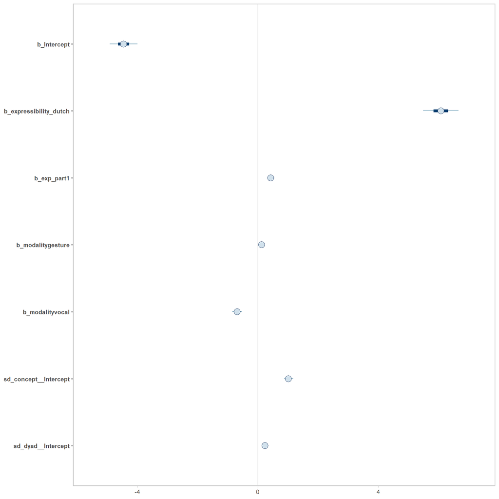

**Figure 102.** Fixed effects’ posterior distributions. Figure generated using [`R`](https://www.r-project.org/) version 4.4.1 (2024-06-14 ucrt)

```r
mcmc_plot(mdl_comb_bin_res);
```

```
## Data were 'prettified'. Consider using `terms="expressibility_dutch
##   [all]"` to get smooth plots.
```

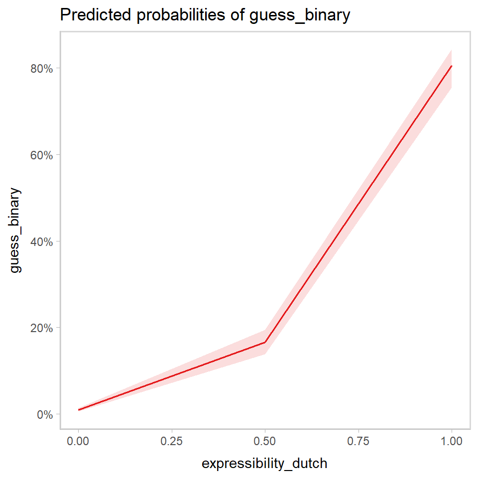

**Figure 103.** Fixed effects. Figure generated using [`R`](https://www.r-project.org/) version 4.4.1 (2024-06-14 ucrt)

```r
plot_model(mdl_comb_bin_res, type="emm", terms=c("expressibility_dutch"));
```

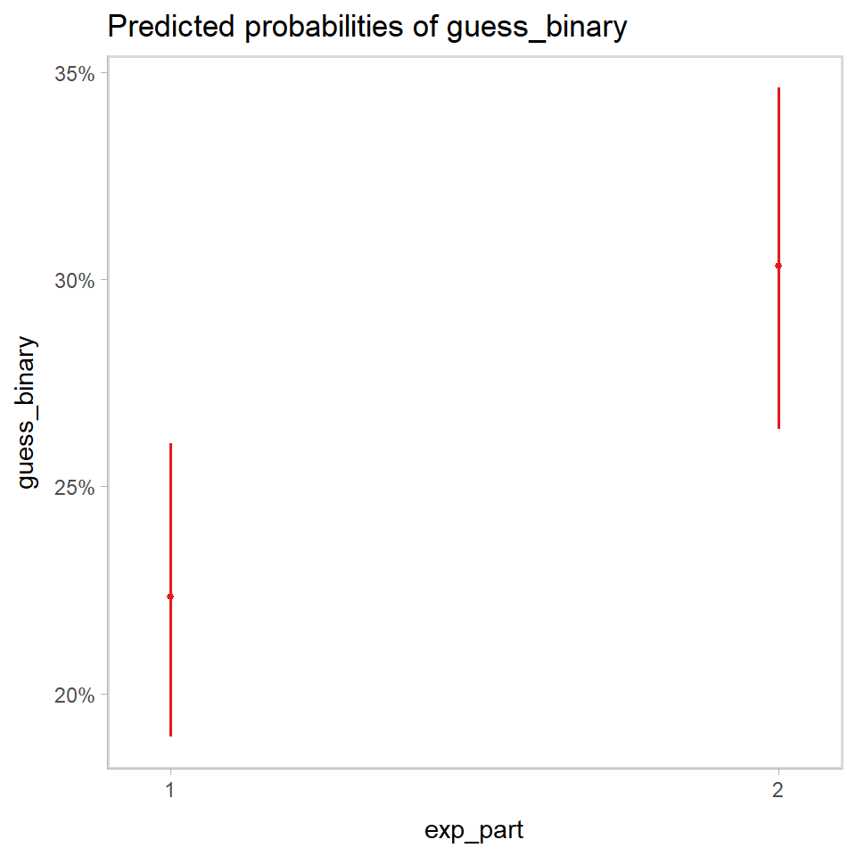

**Figure 103.** Fixed effects. Figure generated using [`R`](https://www.r-project.org/) version 4.4.1 (2024-06-14 ucrt)

```r
plot_model(mdl_comb_bin_res, type="emm", terms=c("exp_part"));
```

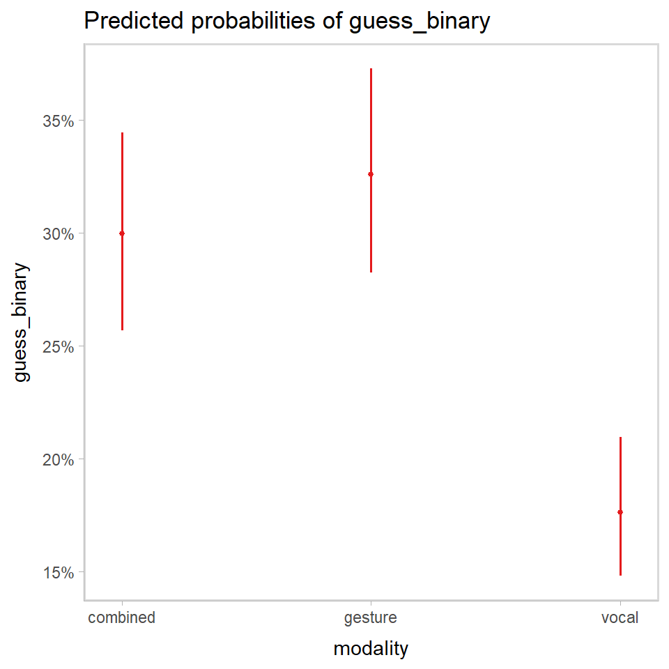

**Figure 103.** Fixed effects. Figure generated using [`R`](https://www.r-project.org/) version 4.4.1 (2024-06-14 ucrt)

```r
plot_model(mdl_comb_bin_res, type="emm", terms=c("modality"));
```

```r
# because of the logit link, it needs to be backtransformed
emmeans(mdl_comb_bin_res, ~ expressibility_dutch, type = "response")
```

```
##  expressibility_dutch response lower.HPD upper.HPD
##                 0.595    0.262     0.216     0.308
##
## Results are averaged over the levels of: exp_part, modality
## Point estimate displayed: median
## Results are back-transformed from the logit scale
## HPD interval probability: 0.95
```

```r
emmeans(mdl_comb_bin_res, ~ exp_part, type = "response")
```

```
##  exp_part response lower.HPD upper.HPD
##  1           0.223     0.180     0.267
##  2           0.303     0.251     0.353
##
## Results are averaged over the levels of: modality
## Point estimate displayed: median
## Results are back-transformed from the logit scale
## HPD interval probability: 0.95
```

```r
emmeans(mdl_comb_bin_res, ~ modality, type = "response")
```

```
##  modality response lower.HPD upper.HPD
##  combined    0.300     0.248     0.355
##  gesture     0.326     0.273     0.384
##  vocal       0.176     0.141     0.215
##
## Results are averaged over the levels of: exp_part
## Point estimate displayed: median
## Results are back-transformed from the logit scale
## HPD interval probability: 0.95
```

```r
pairs(emmeans(mdl_comb_bin_res, ~ exp_part, type = "response"))
```

```
##  contrast              odds.ratio lower.HPD upper.HPD
##  exp_part1 / exp_part2       0.66     0.583     0.739
##
## Results are averaged over the levels of: modality
## Point estimate displayed: median
## Results are back-transformed from the log odds ratio scale
## HPD interval probability: 0.95
```

```r
pairs(emmeans(mdl_comb_bin_res, ~ modality, type = "response"))
```

```
##  contrast           odds.ratio lower.HPD upper.HPD
##  combined / gesture      0.886     0.776      1.00
##  combined / vocal        2.002     1.651      2.39
##  gesture / vocal         2.258     1.880      2.68
##
## Results are averaged over the levels of: exp_part
## Point estimate displayed: median
## Results are back-transformed from the log odds ratio scale
## HPD interval probability: 0.95
```

```r
bayestestR::hdi(mdl_comb_bin_res, ci=0.95)
```

|  | Parameter | CI | CI_low | CI_high | Effects | Component |
| --- | --- | --- | --- | --- | --- | --- |
| 3 | b_Intercept | 0.95 | -5.021835314 | -3.9200571 | fixed | conditional |
| 2 | b_expressibility_dutch | 0.95 | 5.384460472 | 6.7744782 | fixed | conditional |
| 1 | b_exp_part1 | 0.95 | 0.300695059 | 0.5381266 | fixed | conditional |
| 4 | b_modalitygesture | 0.95 | -0.002158005 | 0.2512722 | fixed | conditional |
| 5 | b_modalityvocal | 0.95 | -0.883248744 | -0.5151465 | fixed | conditional |

```r
# experiment part
hypothesis(mdl_comb_bin_res, c("exp_part1 > 0",
                               "(inv_logit_scaled(Intercept + exp_part1)) > (inv_logit_scaled(Intercept - exp_part1))"))
```

```
## Hypothesis Tests for class b:
##                 Hypothesis Estimate Est.Error CI.Lower CI.Upper Evid.Ratio
## 1          (exp_part1) > 0     0.42      0.06     0.32     0.52        Inf
## 2 ((inv_logit_scale... > 0     0.01      0.00     0.01     0.02        Inf
##   Post.Prob Star
## 1         1    *
## 2         1    *
## ---
## 'CI': 90%-CI for one-sided and 95%-CI for two-sided hypotheses.
## '*': For one-sided hypotheses, the posterior probability exceeds 95%;
## for two-sided hypotheses, the value tested against lies outside the 95%-CI.
## Posterior probabilities of point hypotheses assume equal prior probabilities.
```

```r
# modality
hypothesis(mdl_comb_bin_res, c("modalitygesture < 0",
                            "modalityvocal < 0"
                            ))
```

```
## Hypothesis Tests for class b:
##              Hypothesis Estimate Est.Error CI.Lower CI.Upper Evid.Ratio
## 1 (modalitygesture) < 0     0.12      0.06     0.02     0.23       0.03
## 2   (modalityvocal) < 0    -0.69      0.09    -0.85    -0.54        Inf
##   Post.Prob Star
## 1      0.03
## 2      1.00    *
## ---
## 'CI': 90%-CI for one-sided and 95%-CI for two-sided hypotheses.
## '*': For one-sided hypotheses, the posterior probability exceeds 95%;
## for two-sided hypotheses, the value tested against lies outside the 95%-CI.
## Posterior probabilities of point hypotheses assume equal prior probabilities.
```

```r
hypothesis(mdl_comb_bin_res,
  c(# combined better than gesture
    "inv_logit_scaled(Intercept) > inv_logit_scaled(Intercept + modalitygesture)",
    # combined better than vocal
    "inv_logit_scaled(Intercept) > inv_logit_scaled(Intercept + modalityvocal)",
    # gesture better than vocal
    "inv_logit_scaled(Intercept + modalitygesture) > inv_logit_scaled(Intercept + modalityvocal)"
  ))
```

```
## Hypothesis Tests for class b:
##                 Hypothesis Estimate Est.Error CI.Lower CI.Upper Evid.Ratio
## 1 (inv_logit_scaled... > 0     0.00         0        0     0.00       0.03
## 2 (inv_logit_scaled... > 0     0.01         0        0     0.01        Inf
## 3 (inv_logit_scaled... > 0     0.01         0        0     0.01        Inf
##   Post.Prob Star
## 1      0.03
## 2      1.00    *
## 3      1.00    *
## ---
## 'CI': 90%-CI for one-sided and 95%-CI for two-sided hypotheses.
## '*': For one-sided hypotheses, the posterior probability exceeds 95%;
## for two-sided hypotheses, the value tested against lies outside the 95%-CI.
## Posterior probabilities of point hypotheses assume equal prior probabilities.
```

**Intercept**:  
The intercept is -4.46 95%CI [-5.01, -3.91] on the log-odds ratio (LOR) scale. When we convert this value using the inverse-logit transformation, it corresponds to an **overall predicted probability** of a correct guess (when **combined** is the reference modality) of 1.1% 95%CI [0.7%, 2.0%].

**Expressibility**:  
The effect of *expressibility* is 6.08 95%CI [5.39, 6.78] on the log-odds scale. This substantial positive effect suggests that more **expressible** concepts have a significantly higher probability of being guessed correctly. When moving from **low** expressibility (e.g., **0.0**) to **high** expressibility (**1.0**), the predicted probability of a correct guess increases from about 1.1% 95%CI [0.7%, 2.0%] (**low expressibility**) to 83.4% 95%CI [59.2%, 94.6%] (**high expressibility**).

**Experiment part**:  
The effect of *experiment part (feedback = Part 2)* is 0.42 95%CI [0.30, 0.54] on the log-odds scale. This positive effect indicates that **providing feedback (Part 2)** increases the probability of a correct guess. When moving from **no feedback (Part 1)** to **feedback (Part 2)**, the predicted probability of a correct guess changes from 1.1% 95%CI [0.7%, 2.0%] (**Part 1**)  
to 1.7% 95%CI [0.9%, 3.3%] (**Part 2**).

**Modality effects**:

*Gesture*:  
The effect of **gesture** is 0.12 95%CI [-0.01, 0.25] on the log-odds scale.  
Switching from **combined** to **gesture** results in a small, non-significant change in the probability of a correct guess, suggesting **gesture and combined perform similarly**.

*Vocal*:  
The effect of **vocal** is -0.69 95%CI [-0.88, -0.51] on the log-odds scale.  
Switching from **combined** to **vocal** results in a **substantial decrease** in the probability of a correct guess, showing that **vocal-only signals are reliably less effective than both combined and gesture modalities**.

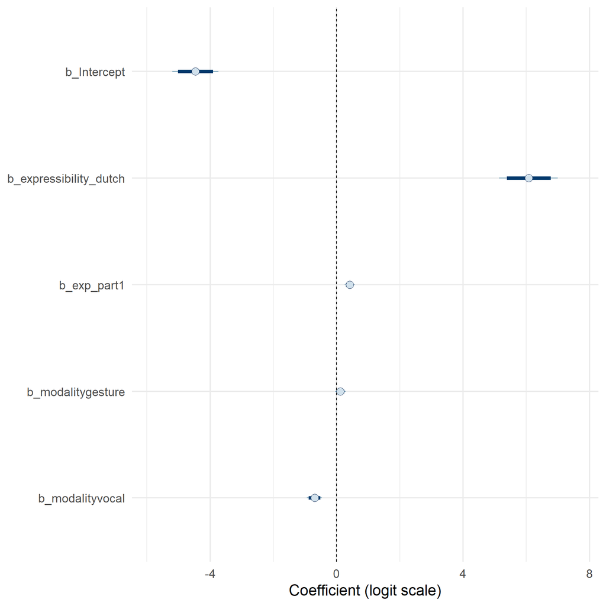

**Figure 104.** Posterior draws for the fixed effects. Figure generated using [`R`](https://www.r-project.org/) version 4.4.1 (2024-06-14 ucrt)

```r
# Extract posterior draws for the fixed effects
# For our binary model, the coefficients are on the logit scale.
posterior_fixed <- as.matrix(mdl_comb_bin_res, variable = "b_.*", regex = TRUE)

# Plot using mcmc_intervals; we add a dashed vertical line at 0 for reference.
mcmc_intervals(posterior_fixed, prob = 0.95, prob_outer = 0.99) +
  geom_vline(xintercept = 0, linetype = "dashed") +
  labs(
    x = "Coefficient (logit scale)"
  ) +
  theme_minimal(base_size = 18)
```

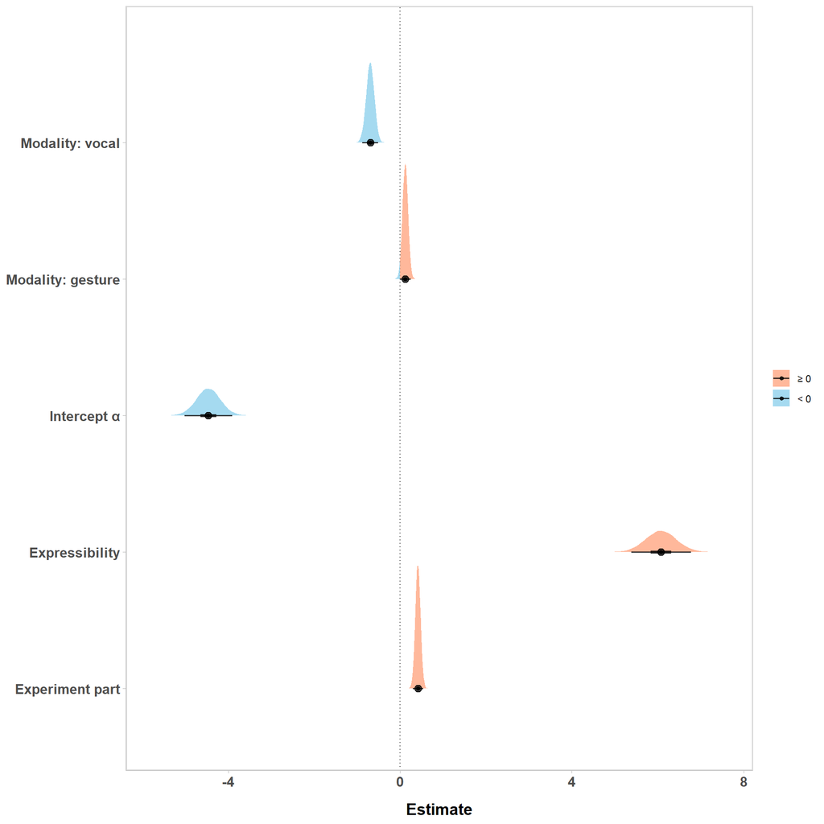

**Figure 105.** Posterior estimates of the fixed effects showing the median (dot), 50% (thick line) and 95% (thin lines) quantiles. Also showing 0 as the vertical dotted line and negative (blue) vs positive (red) values. Figure generated using [`R`](https://www.r-project.org/) version 4.4.1 (2024-06-14 ucrt)

```r
gather_draws(mdl_comb_bin_res, `b_.*`, regex = TRUE) %>%
    # remove the b_ for plotting
    #mutate(.variable = gsub("b_","", .variable)) %>%
    ggplot(aes(x = .value, y = .variable, fill = after_stat(x < 0))) +
    geom_vline(xintercept=0.0, linetype="dotted", color="gray30") +
    stat_halfeye(alpha=0.75, point_interval=median_qi, .width=c(.50, .95)) +
    scale_fill_manual(values = c("lightsalmon", "skyblue"), name=NULL, labels=c("≥ 0", "< 0")) +
    #xlim(-10, 10) +
    scale_y_discrete(labels=c("b_Intercept" = "Intercept α",
                              "b_modalitygesture" = "Modality: gesture",
                              "b_modalityvocal" = "Modality: vocal",
                              "b_expressibility_dutch" = "Expressibility",
                              "b_exp_part1" = "Experiment part")) +
    ylab(NULL) + xlab("Estimate") +
    theme(axis.title.x = element_text(margin = margin(t = 12, b = 0,
                                                      r = 0, l = 0),
                                      face = 'bold', size = 14),
          axis.text.x = element_text(face = 'bold', size = 12),
          axis.text.y = element_text(face = 'bold', size = 12))
```

**Random effects**:

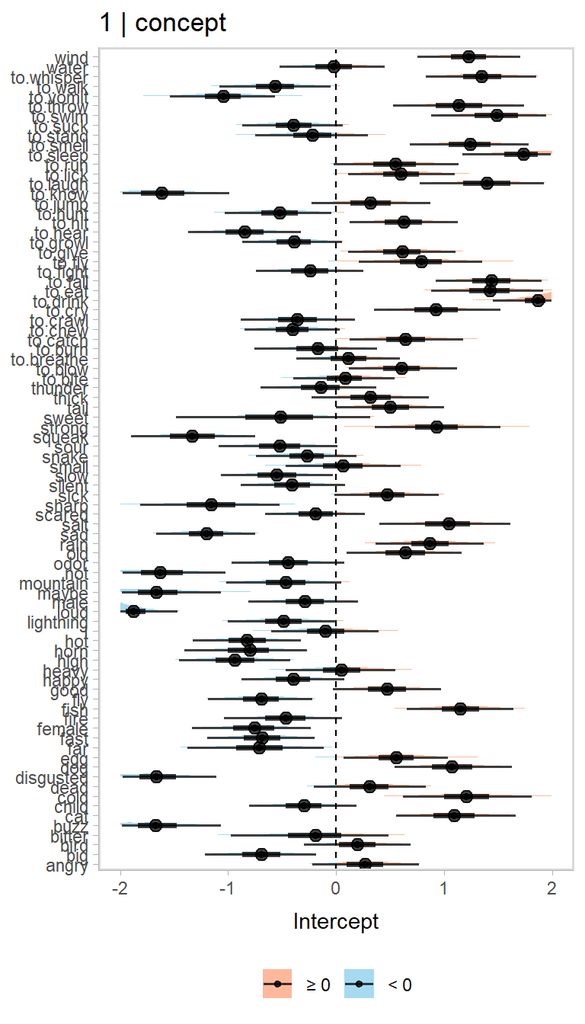

**Figure 106.** Posterior estimates of the random effects showing the median (dot), 50% (thick line) and 95% (thin lines) quantiles. Also showing 0 as the vertical dotted line and negative (blue) vs positive (red) values. Figure generated using [`R`](https://www.r-project.org/) version 4.4.1 (2024-06-14 ucrt)

```r
#get_variables(b1_res_field$b1);
grid.arrange(
  # 1 | concept:
  mdl_comb_bin_res %>%
    spread_draws(b_Intercept, r_concept[concept]) %>%
    #filter(Order == "Intercept") %>%
    mutate(condition_mean = r_concept) %>%
    ggplot(aes(y = concept, x = condition_mean, fill = after_stat(x < 0))) +
    stat_halfeye(alpha=0.75, point_interval=median_qi, .width=c(.50, .95)) +
    scale_fill_manual(values = c("lightsalmon", "skyblue"), name=NULL, labels=c("≥ 0", "< 0")) +
    geom_vline(xintercept = 0, linetype = "dashed") +
    ggtitle("1 | concept") + xlab("Intercept") + ylab(NULL) + xlim(-2,2) +
    theme(legend.position="bottom"),
  nrow=1)
```

Get a general overview of group-level effects.

| Random Effect | Estimate | Est.Error | Q2.5 | Q97.5 |
| --- | --- | --- | --- | --- |
| Intercept | 1.009625 | 0.09087881 | 0.8456242 | 1.204082 |

| Random Effect | Estimate | Est.Error | Q2.5 | Q97.5 |
| --- | --- | --- | --- | --- |
| Intercept | 0.2327707 | 0.04198817 | 0.1508689 | 0.3162199 |

There variance across different concepts is much larger than the variance across different dyads.